# HW3_part0

## 目的:蒐集今年大爆冷門的法國vs阿根廷當夜鄉民討論的內容，找出當時討論趨勢，並看看能否從中發現什麼端倪。

```r
library(bitops)
library(httr)
library(XML)
library(RCurl)
library(tm)
library(NLP)
library(tmcn)
library(jiebaRD)
library(jiebaR)
library(dplyr)
```

```r
library(tm)
library(knitr)
library(ggplot2)
library(factoextra)
library(Matrix)
library(tmcn)
```

1.爬蟲世足「法國對阿根廷賭盤開始」~「賽事結束」的世足板

```r
from <- 1217 # 2018-06-29
to   <- 1226 # 2018-06-30
prefix = "https://www.ptt.cc/bbs/WorldCup/index"

data <- list()
for( id in c(from:to) )
{
  url  <- paste0( prefix, as.character(id), ".html" )
  html <- htmlParse( GET(url) )
  url.list <- xpathSApply( html, "//div[@class='title']/a[@href]", xmlAttrs )
  data <- rbind( data, as.matrix(paste('https://www.ptt.cc', url.list, sep='')) )
}
data <- unlist(data)

head(data)
```

[output not shown]

2.依照小時分類做出24個txt檔

```r
getdoc <- function(url)
{
  html <- htmlParse( getURL(url) )
  doc  <- xpathSApply( html, "//div[@id='main-content']", xmlValue )
  time <- xpathSApply( html, "//*[@id='main-content']/div[4]/span[2]", xmlValue )
  temp <- gsub( "  ", " 0", unlist(time) )
  part <- strsplit( temp, split=" ", fixed=T )
  #date <- paste(part[[1]][2], part[[1]][3], part[[1]][5], sep="-")
  #date <- paste(part[[1]][2], part[[1]][5], sep="_")
  #date <- paste(part[[1]][1], part[[1]][2], sep="_")
  timestamp <- part[[1]][4]
  timestamp <- strsplit( timestamp, split=":", fixed=T )
  hour <- timestamp[[1]][1]
  #print(hour)
  name <- paste0('./DATA/', hour, ".txt")
  write(doc, name, append = TRUE)
}

sapply(data, getdoc)
```

3.建立文本資料結構與基本文字清洗

```r
d.corpus <- Corpus(DirSource("DATA") )
d.corpus <- tm_map(d.corpus, removePunctuation)
d.corpus <- tm_map(d.corpus, removeNumbers)
d.corpus <- tm_map(d.corpus, function(word) {
  gsub("[A-Za-z0-9]", "", word)
})
```

4.斷詞

```r
mixseg = worker()
jieba_tokenizer = function(d)
{
  unlist( segment(d[[1]], mixseg) )
}
seg = lapply(d.corpus, jieba_tokenizer)

count_token = function(d)
{
  as.data.frame(table(d))
}
tokens = lapply(seg, count_token)

n = length(seg)
TDM = tokens[[1]]
colNames <- names(seg)
colNames <- gsub(".txt", "", colNames)
for( id in c(2:n) )
{
  TDM = merge(TDM, tokens[[id]], by="d", all = TRUE)
  names(TDM) = c('d', colNames[1:id])
}
TDM[is.na(TDM)] <- 0

kable(head(TDM))
```

| d | 00 | 01 | 02 | 03 | 04 | 05 | 06 | 07 | 08 | 09 | 10 | 11 | 12 | 13 | 14 | 15 | 16 | 17 | 18 | 19 | 20 | 21 | 22 | 23 |
| --- | --- | --- | --- | --- | --- | --- | --- | --- | --- | --- | --- | --- | --- | --- | --- | --- | --- | --- | --- | --- | --- | --- | --- | --- |
|  | 27 | 45 | 43 | 11 | 47 | 22 | 1 | 2 | 1 | 5 | 17 | 14 | 1 | 0 | 3 | 10 | 16 | 3 | 1 | 829 | 201 | 186 | 11 | 21 |
| 一 | 10 | 21 | 10 | 14 | 32 | 6 | 1 | 6 | 4 | 20 | 17 | 20 | 8 | 9 | 1 | 0 | 22 | 7 | 6 | 11 | 23 | 49 | 48 | 26 |
| 一下 | 6 | 20 | 7 | 12 | 18 | 10 | 8 | 1 | 10 | 4 | 29 | 17 | 6 | 2 | 17 | 10 | 19 | 20 | 15 | 32 | 42 | 40 | 44 | 40 |
| 一大步 | 3 | 0 | 0 | 0 | 0 | 0 | 0 | 0 | 0 | 0 | 0 | 0 | 0 | 0 | 0 | 0 | 0 | 0 | 0 | 0 | 0 | 0 | 0 | 0 |
| 一支 | 9 | 0 | 0 | 1 | 3 | 3 | 1 | 1 | 1 | 3 | 0 | 0 | 0 | 0 | 3 | 0 | 0 | 1 | 0 | 6 | 3 | 3 | 0 | 3 |
| 一月 | 1 | 1 | 0 | 0 | 3 | 0 | 0 | 0 | 0 | 0 | 0 | 1 | 0 | 0 | 0 | 0 | 3 | 3 | 1 | 0 | 3 | 1 | 3 | 0 |

```r
kable(tail(TDM))
```

|  | d | 00 | 01 | 02 | 03 | 04 | 05 | 06 | 07 | 08 | 09 | 10 | 11 | 12 | 13 | 14 | 15 | 16 | 17 | 18 | 19 | 20 | 21 | 22 | 23 |
| --- | --- | --- | --- | --- | --- | --- | --- | --- | --- | --- | --- | --- | --- | --- | --- | --- | --- | --- | --- | --- | --- | --- | --- | --- | --- |
| 25541 | 變姆 | 0 | 0 | 0 | 0 | 0 | 0 | 0 | 0 | 0 | 0 | 0 | 0 | 0 | 0 | 0 | 0 | 0 | 0 | 0 | 0 | 0 | 0 | 0 | 3 |
| 25542 | 變姆粉 | 0 | 0 | 0 | 0 | 0 | 0 | 0 | 0 | 0 | 0 | 0 | 0 | 0 | 0 | 0 | 0 | 0 | 0 | 0 | 0 | 0 | 0 | 0 | 3 |
| 25543 | 變神 | 0 | 0 | 0 | 0 | 0 | 0 | 0 | 0 | 0 | 0 | 0 | 0 | 0 | 0 | 0 | 0 | 0 | 0 | 0 | 0 | 0 | 0 | 0 | 3 |
| 25544 | 鱒魚 | 0 | 0 | 0 | 0 | 0 | 0 | 0 | 0 | 0 | 0 | 0 | 0 | 0 | 0 | 0 | 0 | 0 | 0 | 0 | 0 | 0 | 0 | 0 | 3 |
| 25545 | 靈活 | 0 | 0 | 0 | 0 | 0 | 0 | 0 | 0 | 0 | 0 | 0 | 0 | 0 | 0 | 0 | 0 | 0 | 0 | 0 | 0 | 0 | 0 | 0 | 7 |
| 25546 | 觀望 | 0 | 0 | 0 | 0 | 0 | 0 | 0 | 0 | 0 | 0 | 0 | 0 | 0 | 0 | 0 | 0 | 0 | 0 | 0 | 0 | 0 | 0 | 0 | 3 |

5.TF-IDF

```r
tf <- apply(as.matrix(TDM[,2:(n+1)]), 2, sum)

library(Matrix)
idfCal <- function(word_doc)
{
  log2( n / nnzero(word_doc) )
}
idf <- apply(as.matrix(TDM[,2:(n+1)]), 1, idfCal)

doc.tfidf <- TDM
# for(x in 1:nrow(TDM))
# {
#   for(y in 2:ncol(TDM))
#   {
#     doc.tfidf[x,y] <- (doc.tfidf[x,y] / tf[y]) * idf[x]
#   }
# }

tempY = matrix(rep(c(as.matrix(tf)), each = length(idf)), nrow = length(idf))
tempX = matrix(rep(c(as.matrix(idf)), each = length(tf)), ncol = length(tf), byrow = TRUE)
doc.tfidf[,2:(n+1)] <- (doc.tfidf[,2:(n+1)] / tempY) * tempX

stopLine = rowSums(doc.tfidf[,2:(n+1)])
delID = which(stopLine == 0)

kable(head(doc.tfidf[delID,1]))
```

| x |
| --- |
| 一下 |
| 一直 |
| 一個 |
| 了 |
| 人 |
| 又 |

```r
kable(tail(doc.tfidf[delID,1]))
```

| x |
| --- |
| 還 |
| 還有 |
| 還是 |
| 覺得 |
| 贏 |
| 讓 |

```r
TDM = TDM[-delID,]
doc.tfidf = doc.tfidf[-delID,]
```

6.取得的重要關鍵字

```r
TopWords = data.frame()
for( id in c(1:n) )
{
  dayMax = order(doc.tfidf[,id+1], decreasing = TRUE)
  showResult = t(as.data.frame(doc.tfidf[dayMax[1:5],1]))
  TopWords = rbind(TopWords, showResult)
}
rownames(TopWords) = colnames(doc.tfidf)[2:(n+1)]
TopWords = droplevels(TopWords)
kable(TopWords)
```

|  | V1 | V2 | V3 | V4 | V5 |
| --- | --- | --- | --- | --- | --- |
| 00 | 非洲 | 白忙 | 全軍覆沒 | 人生 | 很酷 |
| 01 | 生日快樂 | 志瑋 | 口糧 | 亞運 | 蛋糕 |
| 02 | 北歐 | 黑哨 | 挪威 | 卡西 | 隊報 |
| 03 | 張 | 雄雞 | 高盧 | 紅魔 | 幣 |
| 04 | 張 | 紅白 | 三獅 | 軍團 | 連三拉三 |
| 05 | 嘔 | 製造 | 布局 | 電梯 | 企業 |
| 06 | 滑 | 義甲 | 尤文 | 草皮 | 美好未來 |
| 07 | 冷門 | 十六強 | 爆冷 | 強首役 | 硬闖 |
| 08 | 判罰 | 慈善事業 | 國際足聯 | 回放 | 姆湯 |
| 09 | 抽籤 | 三戰 | 濾光鏡 | 厄齊爾 | 重新 |
| 10 | 眼神 | 分紅 | 材質 | 公園 | 圖文 |
| 11 | 勒夫 | 桑 | 保利 | 腐敗 | 解散 |
| 12 | 貪小便宜 | 免費 | 壟斷 | 付費 | 搶攻 |
| 13 | 廣告 | 虧損 | 看不完 | 成功率 | 巴吉歐 |
| 14 | 土耳其 | 拍照 | 德國人 | 伊布 | 總統 |
| 15 | 牙齒 | 磨牙 | 霍霍 | 魔咒 | 丹麥隊 |
| 16 | 奧斯爾 | 能活 | 生命 | 林 | 川口 |
| 17 | 學習 | 厄瓜 | 沙烏地 | 十六年 | 自由式 |
| 18 | 藍白 | 房主 | 畫質 | 宿舍 | 有線 |
| 19 | ︵ | ﹊ | 科 | 蘇州 | ﹀ |
| 20 | 反思 | 大羅 | 清流 | 會師 | 用語 |
| 21 | 華視 | 史萊姆 | 計分 | 聲音 | 廣告 |
| 22 | 天使 | 萬美元 | 圖卡 | 兒子 | 華視 |
| 23 | 張 | 秀場 | 藍白 | 不分軒輊 | 雄雞 |

7.重要關鍵字 TDM merge 視覺化

```r
TDM$d = as.character(TDM$d)
AllTop = as.data.frame( table(as.matrix(TopWords)) )
AllTop = AllTop[order(AllTop$Freq, decreasing = TRUE),]

kable(head(AllTop))
```

|  | Var1 | Freq |
| --- | --- | --- |
| 73 | 張 | 3 |
| 82 | 華視 | 2 |
| 84 | 雄雞 | 2 |
| 101 | 廣告 | 2 |
| 110 | 藍白 | 2 |
| 1 | ︵ | 1 |

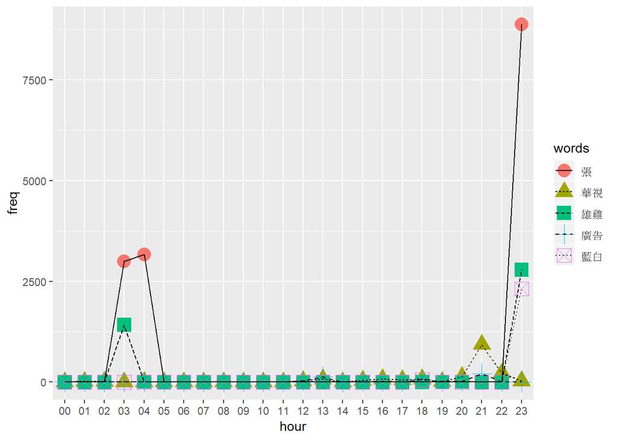

```r
TopNo = 5
tempGraph = data.frame()
for( t in c(1:TopNo) )
{
  word = matrix( rep(c(as.matrix(AllTop$Var1[t])), each = n), nrow = n )
  temp = cbind( colnames(doc.tfidf)[2:(n+1)], t(TDM[which(TDM$d == AllTop$Var1[t]), 2:(n+1)]), word )
  colnames(temp) = c("hour", "freq", "words")
  tempGraph = rbind(tempGraph, temp)
  names(tempGraph) = c("hour", "freq", "words")
}

library(varhandle)
tempGraph$freq = unfactor(tempGraph$freq)
ggplot(tempGraph, aes(hour, freq)) +
  geom_point(aes(color = words, shape = words), size = 5) +
  geom_line(aes(group = words, linetype = words))
```

```r
kable(tail(AllTop))
```

|  | Var1 | Freq |
| --- | --- | --- |
| 108 | 虧損 | 1 |
| 109 | 濾光鏡 | 1 |
| 111 | 壟斷 | 1 |
| 112 | 爆冷 | 1 |
| 113 | 蘇州 | 1 |
| 114 | 魔咒 | 1 |

8.發文時間與發文量

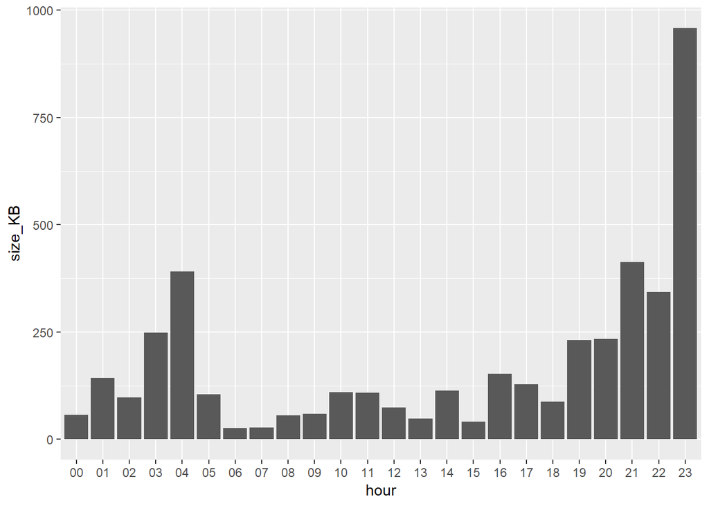

```r
filenames = as.array(paste0("./DATA/",colnames(doc.tfidf)[2:(n+1)],".txt"))
sizeResult = apply(filenames, 1, file.size) / 1024
showSize = data.frame(colnames(doc.tfidf)[2:(n+1)], sizeResult)
names(showSize) = c("hour", "size_KB")

ggplot(showSize, aes(x = hour, y = size_KB)) + geom_bar(stat="identity")
```

9.PCA  
TF-IDF

```r
docs.corpus <- Corpus(DirSource("DATA"))
docs.seg <- tm_map(docs.corpus, segmentCN)
docs.tdm <- TermDocumentMatrix(docs.seg)
docs.tf <- apply(as.matrix(docs.tdm), 2, function(word) { word/sum(word) })
idf <- function(doc) {
  return ( log2( length(doc)+1 / nnzero(doc)) )
}
docs.idf <- apply(as.matrix(docs.tdm), 1, idf)
docs.tfidf <- docs.tf * docs.idf
```

PCA

```r
docs.pca <- prcomp(docs.tfidf, scale = T)
```

### 分析

1.23點是PTT世足板發文數最高的時段  
2.這個時間使用的最高頻率為「張」  
3.回到文本中查詢，發現當時是法國對阿根廷的PTT運彩開獎(23:00多比賽結束，開獎提到下注者各擁有「~張彩券」)  
4.由上可發現今年運彩買氣極高  
5.根據討論度「雄雞」(法國)大於「藍白」(阿根廷)，可發現大量下注者都下在法國  
6.由於阿根廷的高賠率，若此時有人下注阿根廷(或對阿根廷有利的標的)將獲得大量收益  
7.結果出爐，此場比賽大爆冷門